# 🌥⛅Weather Forecasting🌤🌈

### 📈(Prediction at the end)🔮

[figure not shown]

### Context

Weather forecasting is the application of science and technology to predict the conditions of the atmosphere for a given location and time. People have attempted to predict the weather informally for millennia and formally since the 19th century. Weather forecasts are made by collecting quantitative data about the current state of the atmosphere, land, and ocean and using meteorology to project how the atmosphere will change at a given place.

Once calculated manually based mainly upon changes in barometric pressure, current weather conditions, and sky condition or cloud cover, weather forecasting now relies on computer-based models that take many atmospheric factors into account. Human input is still required to pick the best possible forecast model to base the forecast upon, which involves pattern recognition skills, teleconnections, knowledge of model performance, and knowledge of model biases. The inaccuracy of forecasting is due to the chaotic nature of the atmosphere, the massive computational power required to solve the equations that describe the atmosphere, the land, and the ocean, the error involved in measuring the initial conditions, and an incomplete understanding of atmospheric and related processes. Hence, forecasts become less accurate as the difference between current time and the time for which the forecast is being made (the range of the forecast) increases. The use of ensembles and model consensus help narrow the error and provide confidence level in the forecast.

There is a vast variety of end uses to weather forecasts. Weather warnings are important forecasts because they are used to protect life and property. Forecasts based on temperature and precipitation are important to agriculture, and therefore to traders within commodity markets. Temperature forecasts are used by utility companies to estimate demand over coming days. On an everyday basis, many use weather forecasts to determine what to wear on a given day. Since outdoor activities are severely curtailed by heavy rain, snow and wind chill, forecasts can be used to plan activities around these events, and to plan ahead and survive them.

Weather forecasting is a part of the economy, for example, in 2009, the US spent approximately 5.1 billion $ on weather forecasting, producing benefits estimated at six times as much

# Exploratory Data Analysis

## Aim :

- Understand the data ("A small step forward is better than a big one backwards")
- Begin to develop a modelling strategy

## Features

[output not shown]

## Base Chacklist

#### Shape analysis :

- **target(s)** : Next_Tmax & Next_Tmin
- **rows and columns** : 7752 , 25
- **features types** : qualitatives : 1 (la date du relevé) , quantitatives : 24 (tout le reste)
- **NaN analysis** :
  - vraiment pas beaucoup de NaN (moitié des variables = 1% de NaN)

#### Features analysis :

- **Target visualization** :
  - Next_Tmax = 30.27° +/- 3.12°
  - Next_Tmin = 22.930 +/- 2.49°

```python
# This Python 3 environment comes with many helpful analytics libraries installed
# It is defined by the kaggle/python Docker image: https://github.com/kaggle/docker-python
# For example, here's several helpful packages to load

import numpy as np # linear algebra
import pandas as pd # data processing, CSV file I/O (e.g. pd.read_csv)

# Input data files are available in the read-only "../input/" directory
# For example, running this (by clicking run or pressing Shift+Enter) will list all files under the input directory

import os
for dirname, _, filenames in os.walk('/kaggle/input'):
    for filename in filenames:
        print(os.path.join(dirname, filename))

# You can write up to 20GB to the current directory (/kaggle/working/) that gets preserved as output when you create a version using "Save & Run All"
# You can also write temporary files to /kaggle/temp/, but they won't be saved outside of the current session
```

```
/kaggle/input/temperature-forecast-project-using-ml/temp.csv
```

```python
# Importing the libraries
import numpy as np
import matplotlib.pyplot as plt
import pandas as pd
import seaborn as sns
```

```python
# Importing the data set
df = pd.read_csv('/kaggle/input/temperature-forecast-project-using-ml/temp.csv')
```

```python
pd.set_option('display.max_row',25) #Affiche au plus 25 éléments dans les résultats de pandas
pd.set_option('display.max_column',25) #Affiche au plus 25 éléments dans les résultats de pandas
df.head()
```

|  | station | Date | Present_Tmax | Present_Tmin | LDAPS_RHmin | LDAPS_RHmax | LDAPS_Tmax_lapse | LDAPS_Tmin_lapse | LDAPS_WS | LDAPS_LH | LDAPS_CC1 | LDAPS_CC2 | LDAPS_CC3 | LDAPS_CC4 | LDAPS_PPT1 | LDAPS_PPT2 | LDAPS_PPT3 | LDAPS_PPT4 | lat | lon | DEM | Slope | Solar radiation | Next_Tmax | Next_Tmin |
| --- | --- | --- | --- | --- | --- | --- | --- | --- | --- | --- | --- | --- | --- | --- | --- | --- | --- | --- | --- | --- | --- | --- | --- | --- | --- |
| 0 | 1.0 | 30-06-2013 | 28.7 | 21.4 | 58.255688 | 91.116364 | 28.074101 | 23.006936 | 6.818887 | 69.451805 | 0.233947 | 0.203896 | 0.161697 | 0.130928 | 0.0 | 0.0 | 0.0 | 0.0 | 37.6046 | 126.991 | 212.3350 | 2.7850 | 5992.895996 | 29.1 | 21.2 |
| 1 | 2.0 | 30-06-2013 | 31.9 | 21.6 | 52.263397 | 90.604721 | 29.850689 | 24.035009 | 5.691890 | 51.937448 | 0.225508 | 0.251771 | 0.159444 | 0.127727 | 0.0 | 0.0 | 0.0 | 0.0 | 37.6046 | 127.032 | 44.7624 | 0.5141 | 5869.312500 | 30.5 | 22.5 |
| 2 | 3.0 | 30-06-2013 | 31.6 | 23.3 | 48.690479 | 83.973587 | 30.091292 | 24.565633 | 6.138224 | 20.573050 | 0.209344 | 0.257469 | 0.204091 | 0.142125 | 0.0 | 0.0 | 0.0 | 0.0 | 37.5776 | 127.058 | 33.3068 | 0.2661 | 5863.555664 | 31.1 | 23.9 |
| 3 | 4.0 | 30-06-2013 | 32.0 | 23.4 | 58.239788 | 96.483688 | 29.704629 | 23.326177 | 5.650050 | 65.727144 | 0.216372 | 0.226002 | 0.161157 | 0.134249 | 0.0 | 0.0 | 0.0 | 0.0 | 37.6450 | 127.022 | 45.7160 | 2.5348 | 5856.964844 | 31.7 | 24.3 |
| 4 | 5.0 | 30-06-2013 | 31.4 | 21.9 | 56.174095 | 90.155128 | 29.113934 | 23.486480 | 5.735004 | 107.965535 | 0.151407 | 0.249995 | 0.178892 | 0.170021 | 0.0 | 0.0 | 0.0 | 0.0 | 37.5507 | 127.135 | 35.0380 | 0.5055 | 5859.552246 | 31.2 | 22.5 |

```python
df.dtypes.value_counts() # Compte les nombre de types de variables
```

```
float64    24
object      1
dtype: int64
```

```python
df.shape
```

```
(7752, 25)
```

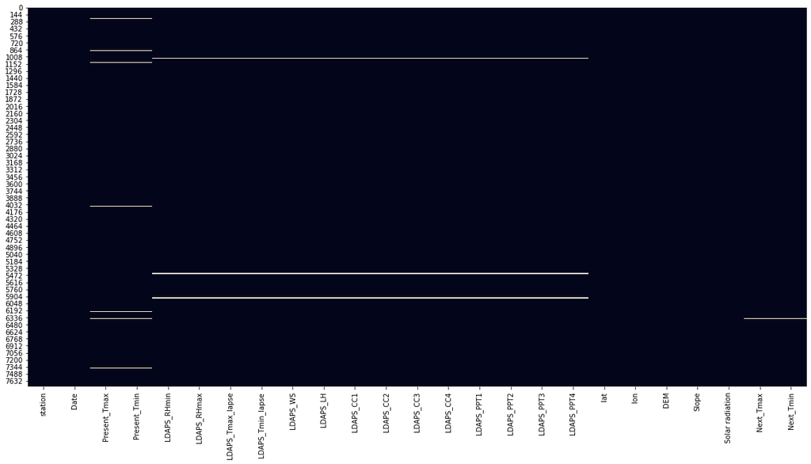

```
LDAPS_CC3           0.967492
LDAPS_PPT4          0.967492
LDAPS_PPT2          0.967492
LDAPS_PPT1          0.967492
LDAPS_CC4           0.967492
LDAPS_CC2           0.967492
LDAPS_CC1           0.967492
LDAPS_LH            0.967492
LDAPS_WS            0.967492
LDAPS_Tmin_lapse    0.967492
LDAPS_Tmax_lapse    0.967492
LDAPS_RHmax         0.967492
LDAPS_RHmin         0.967492
LDAPS_PPT3          0.967492
Present_Tmin        0.902993
Present_Tmax        0.902993
Next_Tmax           0.348297
Next_Tmin           0.348297
Date                0.025800
station             0.025800
lat                 0.000000
lon                 0.000000
DEM                 0.000000
Slope               0.000000
Solar radiation     0.000000
dtype: float64
```

```python
plt.figure(figsize=(20,10))
sns.heatmap(df.isna(),cbar=False)
plt.show()
print((df.isna().sum()/df.shape[0]*100).sort_values(ascending=False))
```

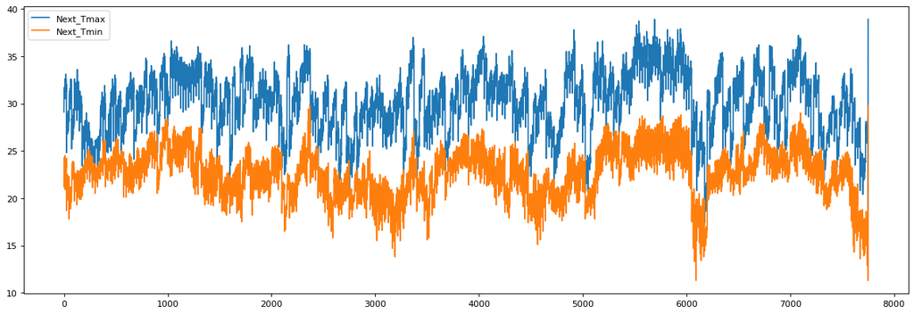

```python
plt.figure(figsize=(18, 6), dpi=80)
plt.plot(df["Next_Tmax"],label="Next_Tmax")
plt.plot(df["Next_Tmin"],label="Next_Tmin")
plt.legend()
plt.show()
```

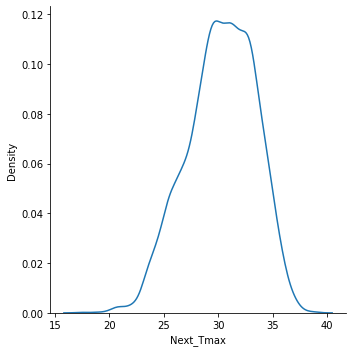

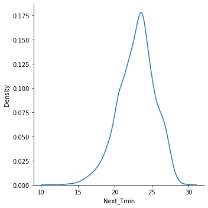

```
30.274886731391593
3.128010057855773
22.93222006472492
2.487612771331068
```

```python
for col in ["Next_Tmax","Next_Tmin"]:
    plt.figure()
    sns.displot(df[col],kind='kde')
    plt.show()
print(df["Next_Tmax"].mean())
print(df["Next_Tmax"].std())
print(df["Next_Tmin"].mean())
print(df["Next_Tmin"].std())
```

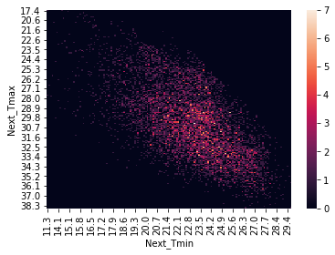

```python
plt.figure()
sns.heatmap(pd.crosstab(df['Next_Tmax'],df['Next_Tmin']))
plt.show()
```

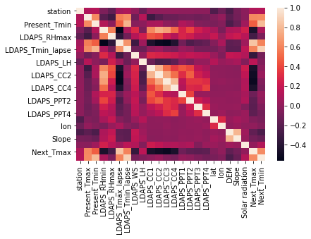

```python
sns.heatmap(df.corr())
```

# Data preprocessing

## Aim :

- Deal with NaN
- Encode qualitative features
- Develop our first modelling strategy

```python
# Importing the data set
df = pd.read_csv('/kaggle/input/temperature-forecast-project-using-ml/temp.csv')
Save = df.copy()
```

```python
def feature_engineering(df):
    df = df.drop(["Date"],axis=1)
    print(df.dtypes.value_counts()) # Compte les nombre de types de variables
    return(df)
```

```python
def imputation(df):
    #df = df.fillna(-999)
    df = df.dropna(axis=0)
    return df
```

```python
def encodage(df):
    return df
```

```python
def preprocessing(df):
    df = imputation(df)
    df = encodage(df)
    df = feature_engineering(df)

    X = df.drop(['Next_Tmax','Next_Tmin'],axis=1)
    y_max = df["Next_Tmax"]
    y_min = df["Next_Tmin"]

    print(X.shape)
    print(y_max.shape)

    return X,y_max,y_min
```

```python
from sklearn.model_selection import train_test_split
trainset, testset = train_test_split(df, test_size=0.2, random_state=0)
```

```python
X_train, y_min_train, y_max_train = preprocessing(trainset)
X_test, y_min_test, y_max_test = preprocessing(testset)
```

```
float64    24
dtype: int64
(6068, 22)
(6068,)
float64    24
dtype: int64
(1520, 22)
(1520,)
```

# Modeling

## Aim :

- Standardise features
- Define a regression model
- Compute score and RMSE (in °C)

## Part 1 - SGDRegressor

```python
from sklearn.pipeline import make_pipeline
from sklearn.preprocessing import StandardScaler
from sklearn.linear_model import SGDRegressor
from sklearn.model_selection import cross_validate
```

```python
reg_max = make_pipeline(StandardScaler(),
                    SGDRegressor(loss='squared_loss', penalty='l2', max_iter=1000, tol=1e-3))
reg_max.fit(X_train, y_max_train)

reg_min = make_pipeline(StandardScaler(),
                    SGDRegressor(loss='squared_loss', penalty='l2', max_iter=1000, tol=1e-3))
reg_min.fit(X_train, y_min_train)

cv_results_min = cross_validate(reg_min, X_train, y_min_train, cv=5, scoring=('r2', "neg_root_mean_squared_error"), return_train_score=True)
cv_results_max = cross_validate(reg_max, X_train, y_max_train, cv=5, scoring=('r2', "neg_root_mean_squared_error"), return_train_score=True)

print('Pour le Next_Tmin :')
print('Test RMSE :' , -cv_results_min['test_neg_root_mean_squared_error'].mean())
print('Test r2 :' , cv_results_min['test_r2'].mean())
print("Train RMSE :" , -cv_results_min['train_neg_root_mean_squared_error'].mean())
print("Train r2 :" , cv_results_min['train_r2'].mean())
print("*------------------------------------------*")
print('Pour le Next_Tmax :')
print('Test RMSE :' , -cv_results_max['test_neg_root_mean_squared_error'].mean())
print('Test r2 :' , cv_results_max['test_r2'].mean())
print("Train RMSE :" , -cv_results_max['train_neg_root_mean_squared_error'].mean())
print("Train r2 :" , cv_results_max['train_r2'].mean())
```

```
Pour le Next_Tmin :
Test RMSE : 1.4710491957080583
Test r2 : 0.7754581562198303
Train RMSE : 1.4675815658054128
Train r2 : 0.7767996956102122
*------------------------------------------*
Pour le Next_Tmax :
Test RMSE : 1.010211731765659
Test r2 : 0.8335435910922501
Train RMSE : 1.0072290803213872
Train r2 : 0.8350208191227744
```

```python
Next_Tmin_predict = reg_min.predict(X_test)
Next_Tmax_predict = reg_max.predict(X_test)
```

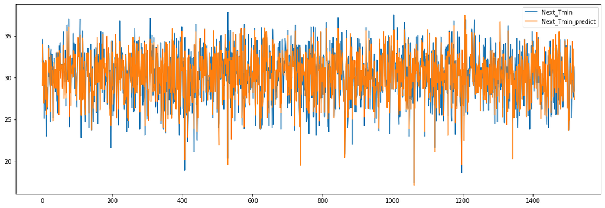

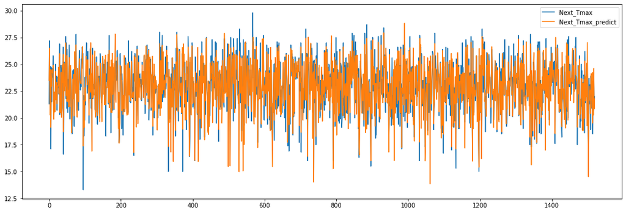

```python
plt.figure(figsize=(18,6))
plt.plot(y_min_test.to_numpy(),label="Next_Tmin")
plt.plot(Next_Tmin_predict,label="Next_Tmin_predict")
plt.legend()
plt.show()

plt.figure(figsize=(18,6))
plt.plot(y_max_test.to_numpy(),label="Next_Tmax")
plt.plot(Next_Tmax_predict,label="Next_Tmax_predict")
plt.legend()
plt.show()
```

## Part 2 - RandomForest

```python
from sklearn.ensemble import RandomForestRegressor
from sklearn.model_selection import GridSearchCV
# Create the parameter grid based on the results of random search
param_grid = {
    'bootstrap': [True],
    'max_depth': [70, 130],
    'max_features': [3, 6],
    'min_samples_leaf': [2, 3],
    'min_samples_split': [4, 8],
    'n_estimators': [1000, 500]
}
# Create a based model
rf = RandomForestRegressor()
# Instantiate the grid search model
grid_search = GridSearchCV(estimator = rf, param_grid = param_grid,
                          cv = 3, n_jobs = -1, verbose = 2)
```

```python
def evaluate(model, test_features, test_labels):
    predictions = model.predict(test_features)
    errors = abs(predictions - test_labels)
    mape = 100 * np.mean(errors / test_labels)
    accuracy = 100 - mape
    print('Model Performance')
    print('Average Error: {:0.4f} degrees.'.format(np.mean(errors)))
    print('Accuracy = {:0.2f}%.'.format(accuracy))

    return accuracy
```

```python
# Fit the grid search to the Max data

grid_search.fit(X_train, y_max_train)
print(grid_search.best_params_)
best_grid = grid_search.best_estimator_
grid_accuracy = evaluate(best_grid, X_test, y_max_test)
```

```
Fitting 3 folds for each of 32 candidates, totalling 96 fits
```

```
[Parallel(n_jobs=-1)]: Using backend LokyBackend with 4 concurrent workers.
[Parallel(n_jobs=-1)]: Done  33 tasks      | elapsed:  1.8min
[Parallel(n_jobs=-1)]: Done  96 out of  96 | elapsed:  5.3min finished
```

```
{'bootstrap': True, 'max_depth': 70, 'max_features': 6, 'min_samples_leaf': 2, 'min_samples_split': 4, 'n_estimators': 1000}
Model Performance
Average Error: 0.5535 degrees.
Accuracy = 97.51%.
```

```python
base_model = RandomForestRegressor(n_estimators = 10, random_state = 42)
base_model.fit(X_train, y_max_train)
base_accuracy = evaluate(base_model, X_test, y_max_test)

print('Improvement of {:0.2f}%.'.format( 100 * (grid_accuracy - base_accuracy) / base_accuracy))
```

```
Model Performance
Average Error: 0.6310 degrees.
Accuracy = 97.16%.
Improvement of 0.36%.
```

```python
# Fit the grid search to the Min data

grid_search.fit(X_train, y_min_train)
print(grid_search.best_params_)
best_grid = grid_search.best_estimator_
grid_accuracy = evaluate(best_grid, X_test, y_min_test)
```

```
Fitting 3 folds for each of 32 candidates, totalling 96 fits
```

```
[Parallel(n_jobs=-1)]: Using backend LokyBackend with 4 concurrent workers.
[Parallel(n_jobs=-1)]: Done  33 tasks      | elapsed:  1.8min
[Parallel(n_jobs=-1)]: Done  96 out of  96 | elapsed:  5.2min finished
```

```
{'bootstrap': True, 'max_depth': 130, 'max_features': 6, 'min_samples_leaf': 2, 'min_samples_split': 4, 'n_estimators': 500}
Model Performance
Average Error: 0.6897 degrees.
Accuracy = 97.68%.
```

```python
base_model = RandomForestRegressor(n_estimators = 10, random_state = 42)
base_model.fit(X_train, y_min_train)
base_accuracy = evaluate(base_model, X_test, y_min_test)

print('Improvement of {:0.2f}%.'.format( 100 * (grid_accuracy - base_accuracy) / base_accuracy))
```

```
Model Performance
Average Error: 0.7870 degrees.
Accuracy = 97.36%.
Improvement of 0.33%.
```

```python
Next_Tmax_TreeRegressor = RandomForestRegressor(random_state = 42,
                                                bootstrap=True, max_depth=110, max_features=4,
                                                min_samples_leaf=2, min_samples_split=4, n_estimators=900)
Next_Tmin_TreeRegressor = RandomForestRegressor(random_state = 42,
                                                bootstrap=True, max_depth=70, max_features=6,
                                                min_samples_leaf=2, min_samples_split=4, n_estimators=900)


print("---Next_Tmax---")
Next_Tmax_TreeRegressor.fit(X_train,y_max_train)
Next_Tmax_Accuracy = evaluate(Next_Tmax_TreeRegressor, X_test, y_max_test)

base_max_model = RandomForestRegressor(n_estimators = 10, random_state = 42)
base_max_model.fit(X_train, y_max_train)
base_max_accuracy = evaluate(base_max_model, X_test, y_max_test)

print('Improvement of {:0.2f}%.'.format( 100 * (Next_Tmax_Accuracy - base_max_accuracy) / base_max_accuracy))
print("---------")


print("---Next_Tmin---")
Next_Tmin_TreeRegressor.fit(X_train,y_min_train)
Next_Tmin_Accuracy = evaluate(Next_Tmin_TreeRegressor, X_test, y_min_test)

base_min_model = RandomForestRegressor(n_estimators = 10, random_state = 42)
base_min_model.fit(X_train, y_min_train)
base_min_accuracy = evaluate(base_min_model, X_test, y_min_test)

print('Improvement of {:0.2f}%.'.format( 100 * (Next_Tmin_Accuracy - base_min_accuracy) / base_min_accuracy))
print("---------")
```

```
---Next_Tmax---
Model Performance
Average Error: 0.5598 degrees.
Accuracy = 97.48%.
Model Performance
Average Error: 0.6310 degrees.
Accuracy = 97.16%.
Improvement of 0.33%.
---------
---Next_Tmin---
Model Performance
Average Error: 0.6888 degrees.
Accuracy = 97.69%.
Model Performance
Average Error: 0.7870 degrees.
Accuracy = 97.36%.
Improvement of 0.33%.
---------
```

# Conclusion

By using RandomForest, we can reach accuracies on both targets up to 97% (+/-0.65°C), which is truely decent.